# Explainability and interpretability of models

Computer-Aided Medical Diagnostics, MPA-PRM (from 2027/28 Applied AI in Life Sciences, MPA-AUI)

Jiří Chmelík

Department of Biomedical Engineering · FEEC, Brno University of Technology

2026-10-03

## Learning goals

Choose before you explain

When is a model that is interpretable by design — from the point scores clinicians use to learned ones — as good as a black box?

Explain a tabular model

Permutation importance, SHAP, PDP and ALE, LIME, Anchors, a surrogate and a counterfactual — on one heart-disease model, with the pitfalls of each.

Explain an image model

Occlusion, Grad-CAM and Integrated Gradients on a chest X-ray classifier — and what a heatmap can and cannot tell you.

Know when not to trust it

Sanity checks — which explanation changes when the model is destroyed — and whether an explanation helps the clinician at all.

SHAP — SHapley Additive exPlanations · PDP — partial dependence plot · ALE — accumulated local effects · LIME — Local Interpretable Model-agnostic Explanations · Grad-CAM — Gradient-weighted Class Activation Mapping

## 1 · Interpretable by design

> Before you explain a black box, ask whether you needed one.

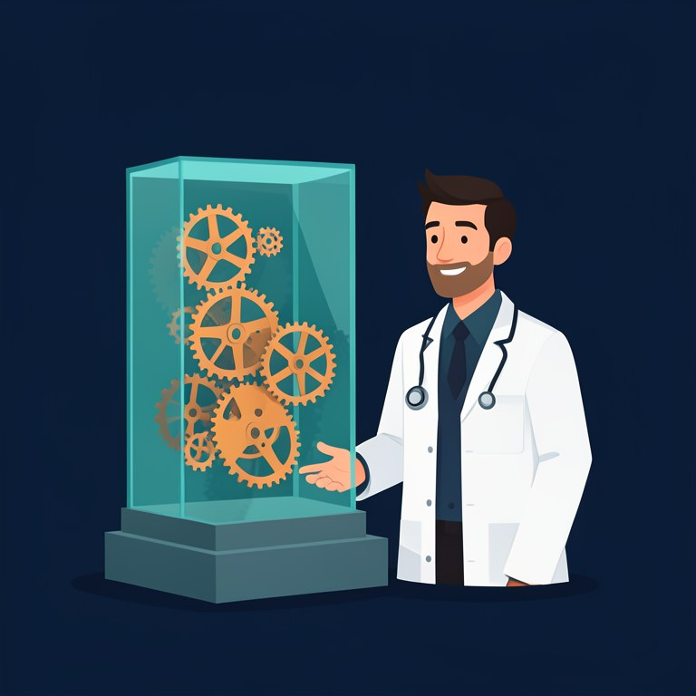

Illustrative image, generated with FLUX.2 [klein] 4B

## Why?

A model flags a patient as high risk.  
The physician asks the only question that matters: **why?**

What would you need to hear back before you act on it?

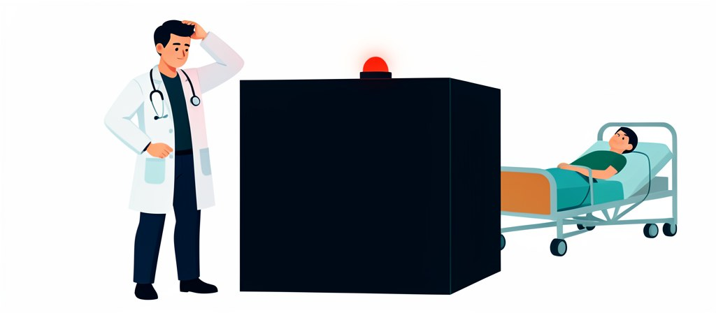

Illustrative image, generated with FLUX.2 [klein] 4B

## You already know interpretable models

- Logistic regression, GAMs, decision trees — from *Machine Learning and Recognition*.
- The coefficients **are** the explanation, nothing is extracted afterwards:

$$\log\frac{p}{1-p} = \beta_0 + \sum_{i} \beta_i x_i$$

**A worked example:** $\beta_0 = -2$, $\beta_{\text{age}} = 0.05$, a patient of 60: log-odds $= -2 + 0.05 \cdot 60 = 1.0$, so $p = \sigma(1.0) \approx 0.73$ — and every year of age adds 0.05 to the log-odds, for every patient.

GAM — generalized additive model

## Clinicians already use this

|  | APACHE II | NEWS2 |
| --- | --- | --- |
| what it is | ICU mortality risk score | ward early-warning score (UK) |
| inputs | about 12 physiological variables | 6 vital signs |
| mechanism | points per variable, summed to a risk | points per vital sign, summed to a trigger |
| weights | set by a clinical committee | set by a clinical committee |

Both are **additive point scores with hand-set weights** — interpretable by construction, trusted for decades, no “AI” label needed.

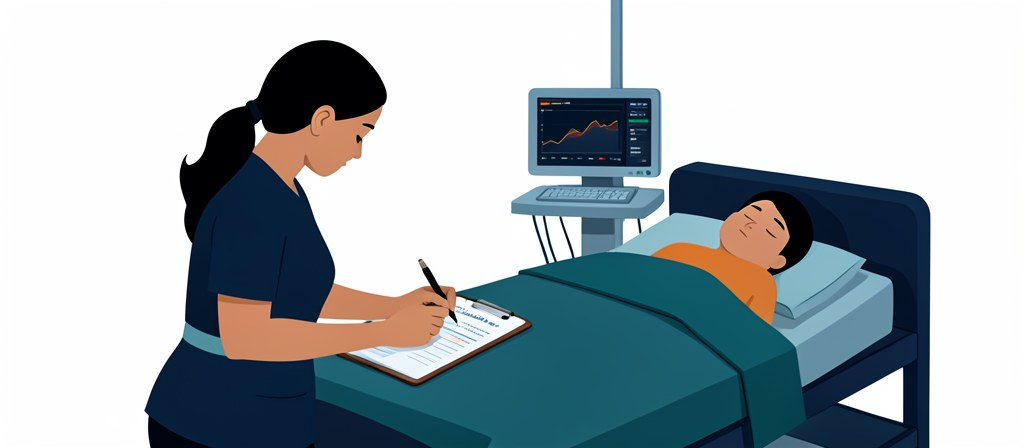

Illustrative image, generated with FLUX.2 [klein] 4B

APACHE II — Acute Physiology And Chronic Health Evaluation II · NEWS2 — National Early Warning Score 2 · ICU — intensive care unit · AI — artificial intelligence

## NEWS2 on one ward patient

[figure not shown]

Royal College of Physicians (2017), *National Early Warning Score (NEWS) 2*; SpO₂ scale 1 · the patient is invented

SpO₂ — peripheral oxygen saturation · BP — blood pressure · CVPU — new Confusion, responds only to Voice or Pain, or Unresponsive

## APACHE II — points inside a logistic regression

- **Score** (0–71) = acute physiology (12 variables, worst value in the first 24 h) + age points + chronic-health points.
- **Risk** of hospital death — a logistic regression on the score:

$$\log\frac{R}{1-R} = -3.517 + 0.146\, s + w_d$$

$s$ — the score, $w_d$ — the weight of the diagnosis (+ 0.603 after emergency surgery).

A patient of 70 (5 age points), physiology 15, no chronic disease: score 20. **Sepsis** ($w_d = +0.113$): log-odds $-0.484$, $R \approx 0.38$. **Drug overdose** ($w_d = -3.353$): $R \approx 0.02$.

[figure not shown]

Knaus et al. (1985), *APACHE II: a severity of disease classification system*, Crit Care Med 13:818–829

## A gallery of point scores

| score | question | items (points) | reading |
| --- | --- | --- | --- |
| **CURB-65** | pneumonia: home, ward or ICU? | confusion, urea > 7 mmol/l, resp. rate ≥ 30, low BP, age ≥ 65 (1 each) | 0–1 home · 2 hospital · ≥ 3 severe |
| **qSOFA** | infection: sepsis risk outside the ICU? | resp. rate ≥ 22, altered mentation, systolic BP ≤ 100 (1 each) | ≥ 2 high risk |
| **CHA₂DS₂-VASc** | atrial fibrillation: anticoagulate? | heart failure, hypertension, age ≥ 75 (2), diabetes, stroke/TIA (2), vascular disease, age 65–74, female sex | 0–9 · higher → anticoagulate |
| **Wells** | how likely is a pulmonary embolism? | signs of DVT (3), PE most likely (3), pulse > 100, immobilisation, previous DVT/PE (1.5 each), haemoptysis, cancer (1 each) | > 4 PE likely |
| **Glasgow Coma Scale** | how deep is the coma? | eyes 1–4, verbal 1–5, motor 1–6 | 3–15 · ≤ 8 severe |
| **Apgar** | how is the newborn at 1 and 5 min? | 5 signs, 0–2 each | 0–10 · ≥ 7 normal |

The same recipe everywhere: a handful of yes/no or banded items, **small integer points**, a sum, a cut-off. A clinician can compute it in their head and check every point.

CURB-65 — Confusion, Urea, Respiratory rate, Blood pressure, age ≥ 65 · qSOFA — quick Sequential Organ Failure Assessment · CHA₂DS₂-VASc — Congestive heart failure, Hypertension, Age ≥ 75, Diabetes, Stroke, VAscular disease, Age 65–74, Sex category · TIA — transient ischaemic attack · DVT — deep vein thrombosis · PE — pulmonary embolism

## Learning the points from data

- Committees choose the points by hand. **RiskSLIM** learns them: the logistic loss of logistic regression, an $\ell_0$ penalty that counts the items, and coefficients restricted to small integers:

$$\min_{\boldsymbol\lambda}\; \frac{1}{n}\sum_{i=1}^{n} \log\left(1 + e^{-y_i \boldsymbol\lambda^\top \mathbf x_i}\right) + C_0 \lVert \boldsymbol\lambda \rVert_0$$

with $\lambda_j \in \{-5, \dots, 5\}$ and $y_i \in \{-1, +1\}$, solved exactly as a mixed-integer program.

2HELPS2B — seizure risk on continuous EEG

brief potentially ictal rhythmic discharges **2** · LPD, LRDA or BIPD **1** · prior seizure **1** · sporadic epileptiform discharges **1** · frequency > 2 Hz **1** · “plus” features **1**

| score | 0 | 1 | 2 | 3 | 4 | 5 | 6–7 |
| --- | --- | --- | --- | --- | --- | --- | --- |
| risk (%) | 5 | 12 | 27 | 50 | 73 | 88 | > 95 |

risk ≈ σ(score − 3) · AUC 0.819 on 5427 EEGs

Ustun, Rudin (2019), [*Learning Optimized Risk Scores*](https://jmlr.org/papers/v20/18-615.html), JMLR · Struck et al. (2017), JAMA Neurol 74:1419–1424

RiskSLIM — Risk-calibrated Supersparse Linear Integer Model · EEG — electroencephalography · LPD — lateralized periodic discharges · LRDA — lateralized rhythmic delta activity · BIPD — bilateral independent periodic discharges · AUC — area under the ROC (receiver operating characteristic) curve

## Rules you can read

- A **decision rule** is an if-then statement — no coefficients to decode.
- **RuleFit** adds rules mined from tree paths to a linear model: linear simplicity, tree-like interactions.

$$f(\mathbf x) = \beta_0 + \sum_i \beta_i x_i + \sum_m \alpha_m\, r_m(\mathbf x)$$

$r_m(\mathbf x) \in \{0, 1\}$ is a rule from a tree path, $\alpha_m$ its weight.

A depth-2 tree on our training patients

IF thallium test is abnormal (thal > 4.5)  
AND chest pain is asymptomatic (cp = 4)  
THEN **60 of 67** patients have the disease (90 %)

IF thal is normal AND no vessel on fluoroscopy  
THEN **10 of 91** (11 %)

Friedman, Popescu (2008), *Predictive Learning via Rule Ensembles* · [Molnar, *Interpretable ML*, Decision Rules / RuleFit](https://christophm.github.io/interpretable-ml-book/rules.html)

ML — machine learning

## The accuracy-versus-interpretability myth

- Common belief: black boxes are more accurate, interpretable models cost you performance.
- On **tabular clinical data** this is often not true — interpretable models are often just as accurate.
- Black boxes win on convenience: they need less feature engineering.

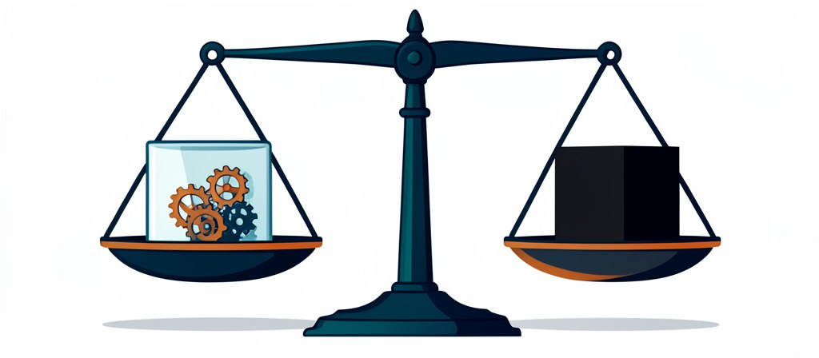

Illustrative image, generated with FLUX.2 [klein] 4B

“Stop explaining black box machine learning models for high stakes decisions and use interpretable models instead.” — Cynthia Rudin, 2019

Rudin (2019), [arXiv:1811.10154](https://arxiv.org/abs/1811.10154)

## Logistic regression or XGBoost?

UCI Heart Disease, 303 patients, the same split, the same 13 features.  
Which model scores higher on the 76 test patients?

Vote before the next slide.

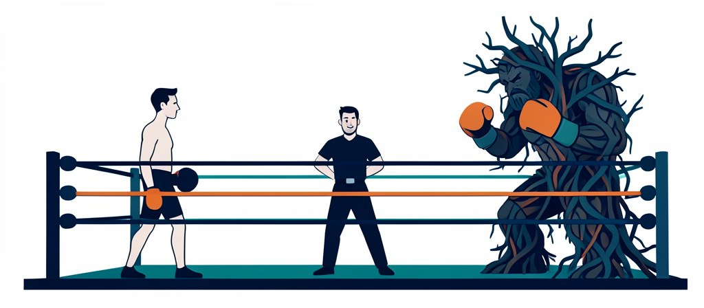

Illustrative image, generated with FLUX.2 [klein] 4B

XGBoost — eXtreme Gradient Boosting · UCI — University of California, Irvine (its Machine Learning Repository)

## The answer

[figure not shown]

The same 75 / 25 split, seed 42. The lab reproduces these numbers in part 1.

## A curve per feature — GAMs

$$\log\frac{p}{1-p} = \beta_0 + \sum_j f_j(x_j)$$

- Each feature gets its own **curve** $f_j$, and the effects still **add up**: readable like a logistic regression, bent like a tree.
- On our patients: accuracy **0.855**, AUC **0.924** — the league of the other two models.
- **EBMs** (InterpretML) learn the curves by boosting.

[figure not shown]

**Why readable matters:** a GAM for pneumonia mortality learned that **asthma lowers the risk** — asthmatics went straight to the ICU. A black box learns the same rule; only the glass box lets you see it and remove it.

Hastie, Tibshirani (1986), *Generalized Additive Models* · Caruana et al. (2015), *Intelligible Models for HealthCare*, KDD · Nori et al. (2019), InterpretML, [arXiv:1909.09223](https://arxiv.org/abs/1909.09223)

EBM — Explainable Boosting Machine

## Interpretable models — strengths and pitfalls

Use it when

- Tabular data with meaningful features: here logistic regression matched XGBoost.
- The whole model must be checked before deployment, weight by weight.
- You want learned artefacts to be **visible and fixable**, not hidden.
- It must run at the bedside without software: points, rules, a chart.

Watch out

- A weight means “**others held fixed**”: age 0.49 alone, 0.002 with the rest.
- Correlated features destabilize weights: ST depression gets −0.02 (alone +0.95).
- Shallow trees are unstable: 100 resamples gave 42 different depth-2 trees (Rashomon).
- Points and bands discard information and miss interactions you did not add.

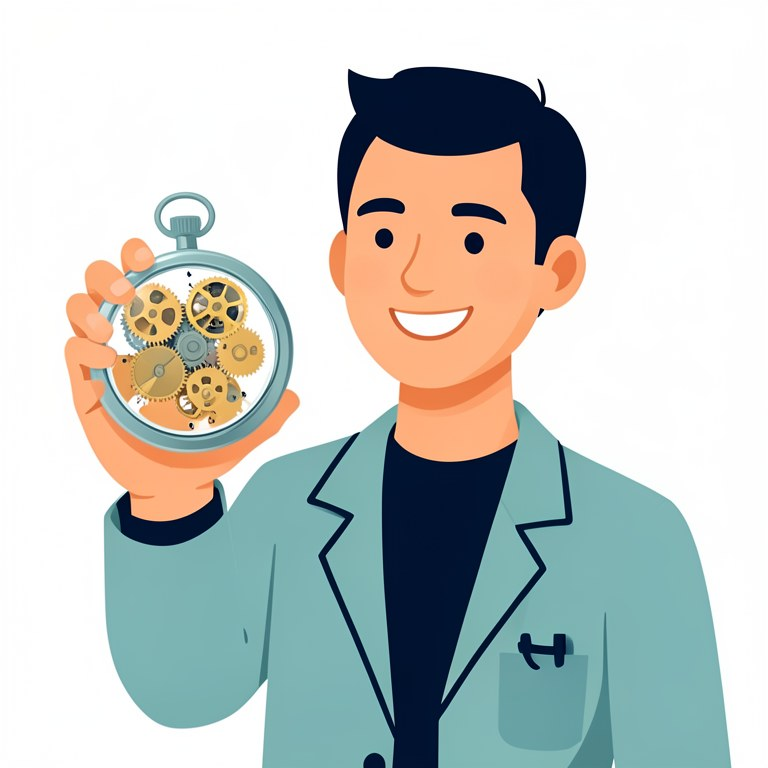

Illustrative image, generated with FLUX.2 [klein] 4B

Interpretable means you can read the model — not that what you read is causal or stable.

Caruana et al. (2015), *Intelligible Models for HealthCare*, KDD · Royston, Altman, Sauerbrei (2006), *Dichotomizing continuous predictors…*, Stat Med

ST depression — depression of the ST segment of the ECG (electrocardiogram)

## 2 · A map of the methods

> Local or global — inside the model or around it.

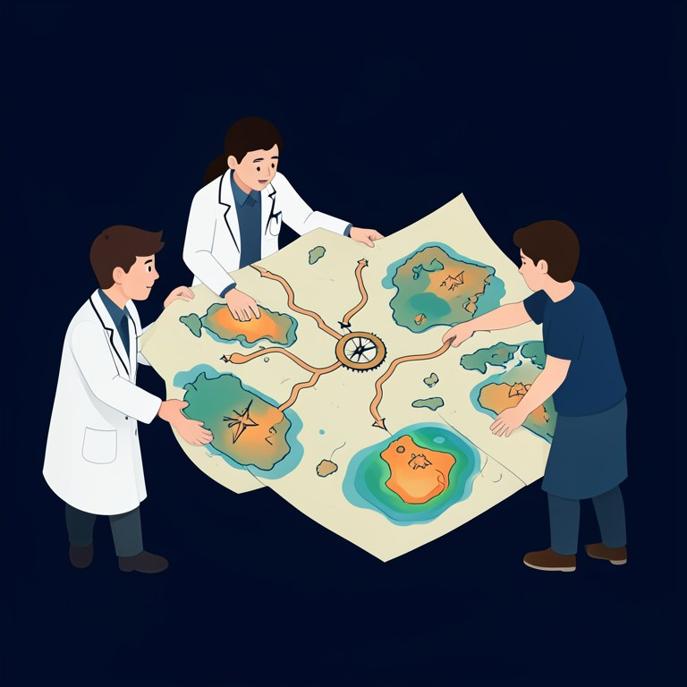

Illustrative image, generated with FLUX.2 [klein] 4B

## A map for everything that follows

|  | model-specific | model-agnostic |
| --- | --- | --- |
| **local** (one prediction) | Grad-CAM · Integrated Gradients | LIME · SHAP · Anchors · counterfactuals · occlusion sensitivity |
| **global** (the whole model) | the model’s own feature importances | permutation importance · PDP / ALE · aggregated SHAP · global surrogate |

Taxonomy after C. Molnar, [*Interpretable Machine Learning*](https://christophm.github.io/interpretable-ml-book/) (free online book)

## The wider landscape

By design

- **linear and logistic regression, GAM, trees**
- **decision rules, RuleFit**
- **prototype networks**
- **concept bottleneck models**

Global, model-agnostic

- **permutation importance**
- **PDP, ICE, ALE**
- **global surrogate**
- feature interaction (H-statistic)

Local, model-agnostic

- **LIME, Anchors**
- **SHAP**
- **counterfactuals**

Local, images

- **occlusion, Grad-CAM**
- **Integrated Gradients**
- **gradients, SmoothGrad, guided backprop**
- layer-wise relevance propagation

Concepts, examples

- **influence functions**
- **prototypes and criticisms**
- feature visualization, TCAV

Is it trustworthy?

- **sanity checks**
- **attention as explanation**
- adversarial examples

**Bold** = covered today; the rest is in the reading list. Categories after Molnar.

ICE — individual conditional expectation · TCAV — Testing with Concept Activation Vectors

## 3 · Explaining a tabular model

> One patient, one model, many ways to ask why.

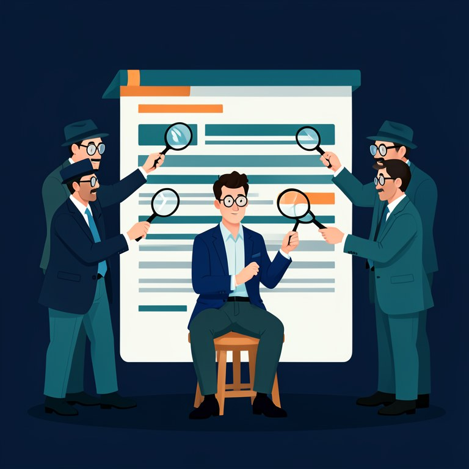

Illustrative image, generated with FLUX.2 [klein] 4B

## Permutation importance

- Shuffle **one feature’s values** in the test set, keep the rest, measure the accuracy again.
- A big drop: the model needed the feature. No drop: it did not.
- Global, model-agnostic, no retraining.

$$\mathrm{PI}_j = s(f, X, \mathbf y) - \frac{1}{K}\sum_{k=1}^{K} s\big(f, X_{\pi_j^{(k)}}, \mathbf y\big)$$

- $s$ — a score, here the accuracy;
- $X_{\pi_j^{(k)}}$ — the test set with column $j$ shuffled, the $k$-th time;
- averaged over $K = 30$ shuffles.

**On our model:** accuracy 0.868. Shuffling the number of vessels on fluoroscopy costs 0.080 on average; fasting blood sugar costs **0.000** — shuffling it never changes a single prediction.

Breiman (2001), *Random Forests* · Fisher, Rudin, Dominici (2019), [arXiv:1801.01489](https://arxiv.org/abs/1801.01489)

## Which features does the model need?

[figure not shown]

## Permutation importance — strengths and pitfalls

Use it when

- You need a quick global ranking for **any** model and any metric.
- It is computed on **held-out** data: it shows what generalizes.
- Correlated features **can** be permuted together, as one group.

Watch out

- Correlated twins: an exact copy of `ca` gets 0.000, swap the columns — `ca` gets 0.000.
- Shuffled rows are **impossible patients**: the model is tested off the data.
- On training data it rewards memorization: age 0.081 there, 0.036 on test.
- It measures what the **model** uses — not what causes the disease.

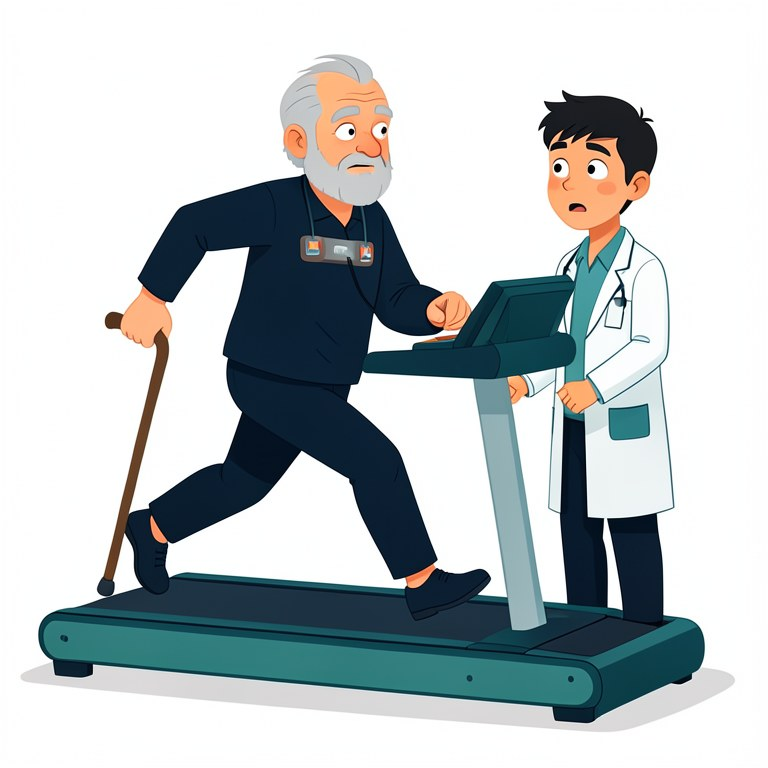

Illustrative image, generated with FLUX.2 [klein] 4B

Before you read the bars, look at the correlation matrix: twins share or steal each other’s importance.

Strobl et al. (2008), *Conditional variable importance for random forests*, BMC Bioinformatics · Hooker, Mentch, Zhou (2021), *Unrestricted permutation forces extrapolation*, Stat Comput

## SHAP — one framework for the credit

Cooperative game theory: the features are **players**, the prediction is the **payout**, and the Shapley value is a feature’s fair average contribution over all coalitions of the others.

**players**

the features

→

**every coalition**

of the other features

→

**marginal contribution**

with and without the feature

→

**average**

the Shapley value $\phi_i$

- **Local accuracy:** the $\phi_i$ add up exactly to $f(\mathbf x) - \phi_0$.
- **Consistency:** a feature that matters more never gets less credit.

Lundberg, Lee (2017), [arXiv:1705.07874](https://arxiv.org/abs/1705.07874) · [shap.readthedocs.io](https://shap.readthedocs.io/)

## The math behind SHAP

$$\phi_i = \sum_{S \subseteq F \setminus \{i\}} \frac{|S|!\,(|F| - |S| - 1)!}{|F|!}\,\Big[f(S \cup \{i\}) - f(S)\Big]$$

- $S$ is a subset of the features without $i$, $f(S)$ the model using only the features in $S$; the fraction weights each subset by the number of orderings of all features that produce it.

**Two features, both orderings:** $f(\varnothing) = 0.10$, $f(\{A\}) = 0.40$, $f(\{B\}) = 0.20$, $f(\{A, B\}) = 0.60$. $\phi_A = \tfrac12\big[(0.40 - 0.10) + (0.60 - 0.20)\big] = 0.35$, $\phi_B = \tfrac12\big[(0.20 - 0.10) + (0.60 - 0.40)\big] = 0.15$ — and $0.10 + 0.35 + 0.15 = 0.60$.

## Three real patients

[figure not shown]

TreeSHAP in log-odds; base value −0.175 (P = 0.46, the average of the model).

## From three waterfalls to all 76 patients

[figure not shown]

The SHAP summary (“beeswarm”) plot — `shap.plots.beeswarm` in the lab; here drawn by `figures_tabular.beeswarm`.

## SHAP — strengths and pitfalls

Use it when

- You need a per-patient audit that **adds up exactly** to the prediction.
- The model is a tree ensemble: TreeSHAP is exact and fast.
- One computation gives both the local waterfall and a global ranking.

Watch out

- Correlated twins: an exact copy of `ca` gets mean |SHAP| 0.000, `ca` keeps 1.239.
- Values are in **log-odds**: +1.15 means +0.27 at P 0.46, +0.07 at P 0.90.
- The answer depends on the background data and on how features are “removed”.
- Outside trees, KernelSHAP is slow, sampled — and can be fooled.

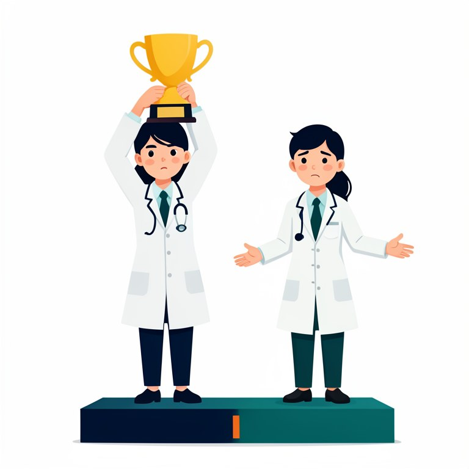

Illustrative image, generated with FLUX.2 [klein] 4B

A SHAP value is a fair split of the **model’s** output — fair to the model, not proof about the patient.

Chen et al. (2020), *True to the Model or True to the Data?*, [arXiv:2006.16234](https://arxiv.org/abs/2006.16234) · Slack et al. (2020), *Fooling LIME and SHAP*, AIES

## From one patient to the population

- **Ceteris paribus:** one patient, one feature moved across a grid.
- **ICE:** the same for every patient — a bundle of curves.
- **PDP:** the mean of the bundle — “the effect on average”.
- **ALE:** PDP puts every patient at every value, including combinations that never occur. ALE moves only the patients **near** each value.

$$\widehat{\mathrm{PDP}}(v) = \frac{1}{n}\sum_{k=1}^{n} f\big(v, \mathbf x_k^{\setminus j}\big)$$

$$\widehat{\mathrm{ALE}}(v) = \int_{z_0}^{v} \mathrm{E}\Big[\frac{\partial f}{\partial x_j}\,\Big|\,X_j = z\Big]\,dz$$

**PDP at age 70:** all 76 test patients made 70 years old — mean P(disease) 0.483, including a 70-year-old with the heart rate of a 35-year-old.

Friedman (2001), *Greedy Function Approximation* · Apley, Zhu (2020), [arXiv:1612.08468](https://arxiv.org/abs/1612.08468)

## PDP and ALE on our model

[figure not shown]

## PDP, ICE and ALE — strengths and pitfalls

Use it when

- You want the **shape** of an effect — a dose-response curve of the model.
- ICE shows whether patients respond differently, not just on average.
- ALE stays on the data when features correlate — and is cheaper.

Watch out

- PDP visits impossible patients: only 3 of 303 are ≥ 65 with heart rate ≥ 165.
- An average can hide everything: age PDP +0.03, single ICE curves −0.37 to +0.71.
- ALE depends on the bins and is read locally, without per-patient curves.
- The tails rest on a handful of patients — draw where the data are.

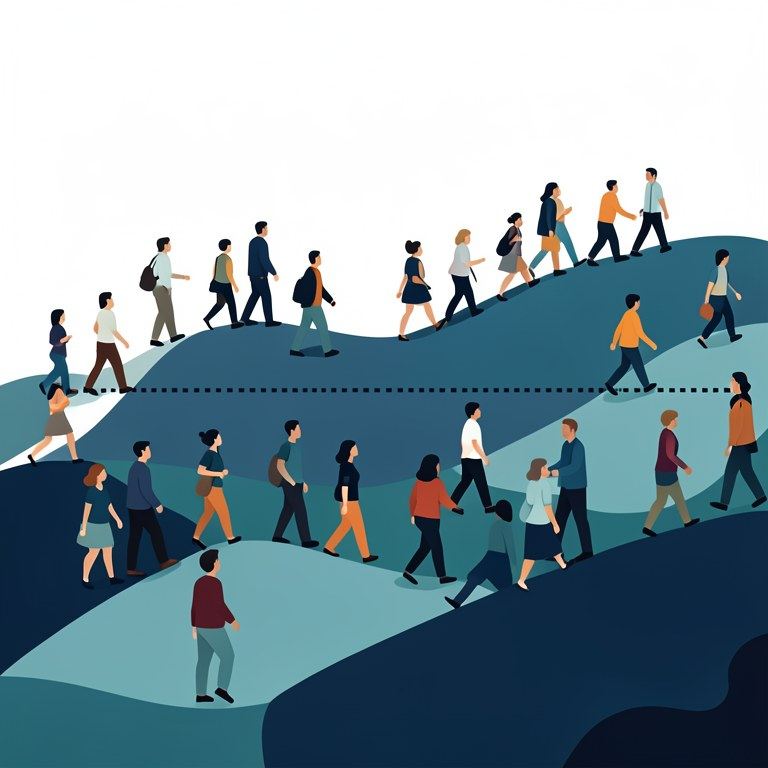

Illustrative image, generated with FLUX.2 [klein] 4B

Plot PDP and ALE together with the ICE curves and a rug of the data; trust only where they agree.

Goldstein et al. (2015), *Peeking Inside the Black Box: … ICE*, J Comput Graph Stat · Apley, Zhu (2020), JRSS B · [Molnar, *Interpretable ML*, ALE](https://christophm.github.io/interpretable-ml-book/ale.html)

## LIME — explain locally with a simple model

- Perturb the input around one prediction.
- Ask the black box about every perturbed point.
- Fit a **simple surrogate** — a weighted linear model — to its answers near that point.
- The surrogate’s coefficients are the explanation, valid **only in that neighbourhood**.

Ribeiro, Singh, Guestrin (2016), *“Why Should I Trust You?”*, [arXiv:1602.04938](https://arxiv.org/abs/1602.04938) · github.com/marcotcr/lime

## The math behind LIME

$$\xi(\mathbf x) = \arg\min_{g \in G}\; \mathcal L\big(f, g, \pi_{\mathbf x}\big) + \Omega(g)$$

- $g$ — a simple surrogate from a family $G$;
- $\pi_{\mathbf x}$ — a kernel that weighs points near $\mathbf x$ more;
- $\mathcal L$ — how unfaithful $g$ is to $f$ under that weighting;
- $\Omega(g)$ — a penalty that keeps $g$ readable.

**The kernel** $\pi_{\mathbf x}(\mathbf z) = e^{-d^2 / 2\sigma^2}$ with $\sigma = 0.25$: a point at $d = 0.1$ weighs $e^{-0.08} \approx 0.92$, one at $d = 0.5$ weighs $e^{-2} \approx 0.14$.

[figure not shown]

## LIME vs. SHAP

|  | LIME | SHAP |
| --- | --- | --- |
| basis | a local weighted surrogate | Shapley values, game theory |
| guarantee | none | local accuracy, consistency |
| cost | one local fit | exact for trees (TreeSHAP), sampled otherwise |
| stability | changes with the sample and the kernel | TreeSHAP deterministic; KernelSHAP sampled |

They do not always agree on the same prediction — and when they disagree, the kernel width of LIME is the first suspect.

## LIME — strengths and pitfalls

Use it when

- Any model and any input: tables, text, images split into superpixels.
- A short, sparse local story for one patient is enough.
- A quick sanity check of a model you can only query.

Watch out

- Kernel width and sampling change the answer — the table’s stability row.
- Features are sampled independently: unrealistic patients the model never saw.
- A model can spot the perturbations and hide its bias from LIME.
- Valid only in a neighbourhood nobody defined clinically.

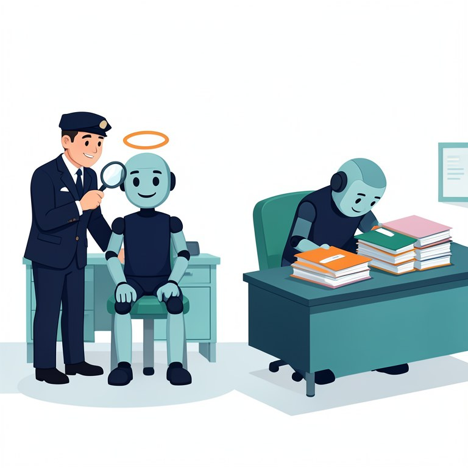

Illustrative image, generated with FLUX.2 [klein] 4B

Never trust a single LIME run: repeat it with other seeds and kernel widths and keep only what survives.

Slack et al. (2020), *Fooling LIME and SHAP*, AIES, [arXiv:1911.02508](https://arxiv.org/abs/1911.02508) · Garreau, von Luxburg (2020), *Explaining the Explainer*, AISTATS

## Anchors — rules instead of weights

- The same authors, one step further: an **if-then rule** that “anchors” the prediction — whatever else changes, the prediction stays.
- Comes with a **precision**, estimated by sampling:

$$P\big(f(\mathbf z) = f(\mathbf x) \,\big|\, \mathbf z \text{ satisfies } A\big) \ge \tau$$

Two rules, measured on our model

IF asymptomatic chest pain AND ≥ 1 vessel → high risk  
precision **0.948**, coverage **0.254**

IF age > 55 AND cholesterol > 240 → high risk  
precision **0.675**, coverage **0.274**

Ribeiro, Singh, Guestrin (2018), AAAI, *Anchors* · github.com/marcotcr/anchor

## Anchors — strengths and pitfalls

Use it when

- The clinician wants a rule to read, not a vector of weights.
- Precision and coverage say how far the rule can be trusted.
- Only predictions are needed — any model, like LIME.

Watch out

- High precision usually costs coverage: a sure rule for a handful of patients.
- Near the decision boundary anchors grow long and cover almost nobody.
- An anchor is sufficient, not necessary: high-risk patients exist outside it.
- The library measures precision on perturbed samples, not on real patients.

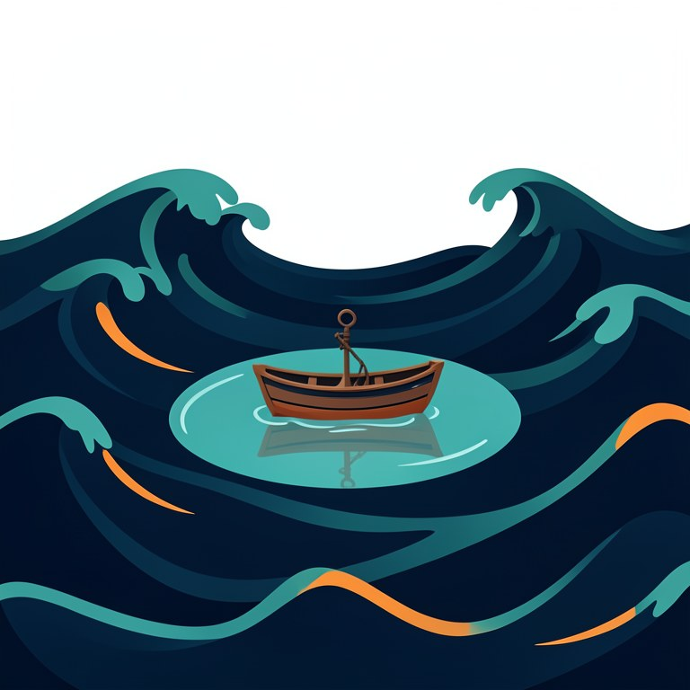

Illustrative image, generated with FLUX.2 [klein] 4B

Read an anchor only with both numbers — precision without coverage is a rule for nobody.

Ribeiro, Singh, Guestrin (2018), *Anchors: High-Precision Model-Agnostic Explanations*, AAAI

## Global surrogate — LIME for the whole model

- LIME fits a simple model **around one point**.
- A **global surrogate** fits a simple model — a shallow tree — to the black box **everywhere**.
- Readable, but only as trustworthy as its **fidelity**.

$$g = \arg\min_{g \in G} \sum_{i=1}^{n} \big(f(\mathbf x_i) - g(\mathbf x_i)\big)^2$$

**On our model:** a depth-3 tree fitted to the XGBoost probabilities of the 227 training patients reproduces them with $R^2 = 0.69$, and those of the 76 test patients with $R^2 = 0.76$.

A quarter of what the black box does is **not** in the tree.

[Molnar, *Interpretable ML*, Global Surrogate](https://christophm.github.io/interpretable-ml-book/global.html)

## Global surrogate — strengths and pitfalls

Use it when

- You want one readable picture of the whole model’s logic.
- Any black box, one scikit-learn call, fidelity directly measurable.
- Checking whether the main splits make clinical sense.

Watch out

- R² is fidelity to the model, not accuracy on patients.
- Fidelity on held-out patients: depth 5 reaches 0.87 on training, 0.57 on test.
- A good average hides regions where the tree and the model disagree.
- A split may use a correlated stand-in for what the model really uses.

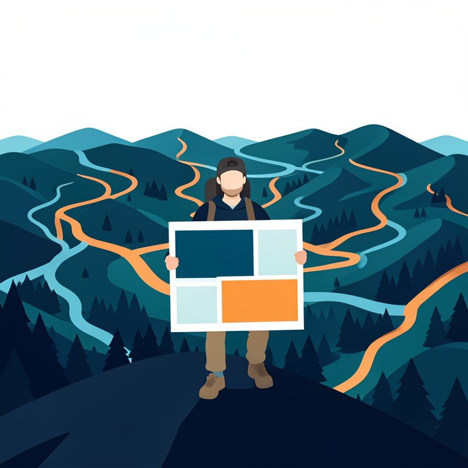

Illustrative image, generated with FLUX.2 [klein] 4B

The tree explains the model only as far as its held-out fidelity reaches — and a deeper tree is not automatically a more faithful one.

## Counterfactuals — what would have to change?

Not *why* the model said “high risk”, but: what is the **smallest change** of this patient that flips the prediction?

- potentially actionable — “this much lower blood pressure and the patient leaves the high-risk band” (if the feature can be changed at all);
- local and model-agnostic, like LIME and SHAP.

**start**

patient $\mathbf x$, high risk

→

**optimize**

the nearest $\mathbf x'$ with another outcome

→

**result**

$\mathbf x'$, low risk

Wachter, Mittelstadt, Russell (2017), [arXiv:1711.00399](https://arxiv.org/abs/1711.00399) · github.com/interpretml/DiCE

## The math behind counterfactuals

$$\arg\min_{\mathbf x'} \max_{\lambda}\; \lambda\big(f(\mathbf x') - y'\big)^2 + d(\mathbf x, \mathbf x')$$

- $y'$ — the target outcome, e.g. low risk;
- $d(\mathbf x, \mathbf x')$ — the cost of the change;
- $\lambda$ — trades “flips the prediction” against “stays close”.

**The figure’s numbers:** $\mathbf x = (1.60, -1.50)$ → $\mathbf x' = (0.39, -1.87)$, $d = \sqrt{1.21^2 + 0.37^2} \approx 1.26$ — the shortest step across the boundary.

[figure not shown]

## Counterfactuals — strengths and pitfalls

Use it when

- The question is “what would change the decision?” — natural for patients.
- Only predictions needed; one concrete example is easy to communicate.
- Probing the model: does it flip on clinically meaningless changes?

Watch out

- The nearest flip often moves age or sex — freeze immutable features.
- Many equally close counterfactuals exist (Rashomon); showing one hides the rest.
- The optimum may be implausible — a patient no data set contains.
- It changes the model’s input, not the patient: not a treatment effect.

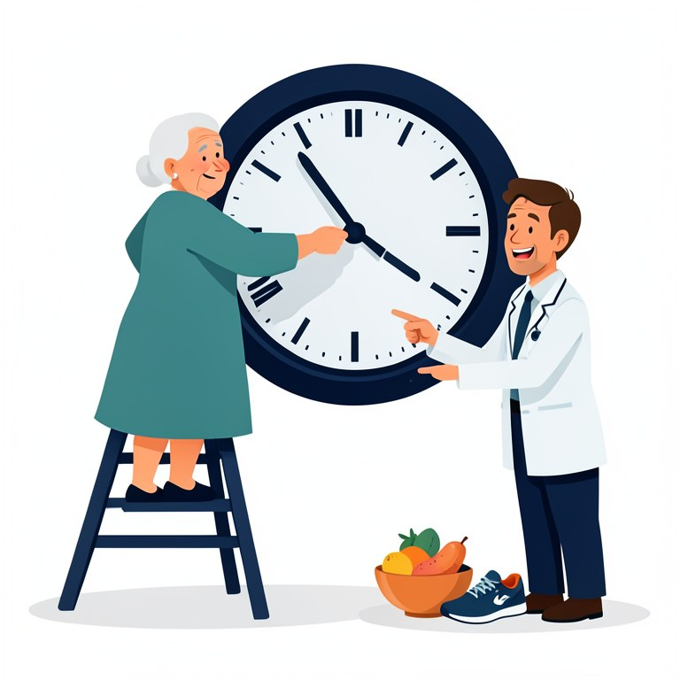

Illustrative image, generated with FLUX.2 [klein] 4B

**On our model:** lowering cholesterol alone brings 11 of the 141 high-risk patients below 0.5; lowering age alone, 26.

Karimi, Schölkopf, Valera (2021), *Algorithmic recourse: from counterfactual explanations to interventions*, FAccT · Mothilal et al. (2020), DiCE, FAT*

DiCE — Diverse Counterfactual Explanations

## Example-based explanations

**Influence functions** — which training point moved *this* prediction?

- How would the prediction change without one training point — without retraining?
- Mislabelled examples tend to be disproportionately influential.

$$\mathcal I(z, z_{\text{test}}) = -\nabla_{\theta} L(z_{\text{test}}, \hat\theta)^\top H_{\hat\theta}^{-1}\, \nabla_{\theta} L(z, \hat\theta)$$

**Prototypes and criticisms** — what does the *whole* data set look like?

- **Prototypes:** a handful of examples that represent the data well.
- **Criticisms:** examples no prototype represents — often an under-served subgroup.

Koh, Liang (2017), [arXiv:1703.04730](https://arxiv.org/abs/1703.04730) · Kim, Khanna, Koyejo (2016), NeurIPS, *Examples are not Enough, Learn to Criticize*

## 4 · Explaining an image model

> A heatmap answers “where”, never “why”.

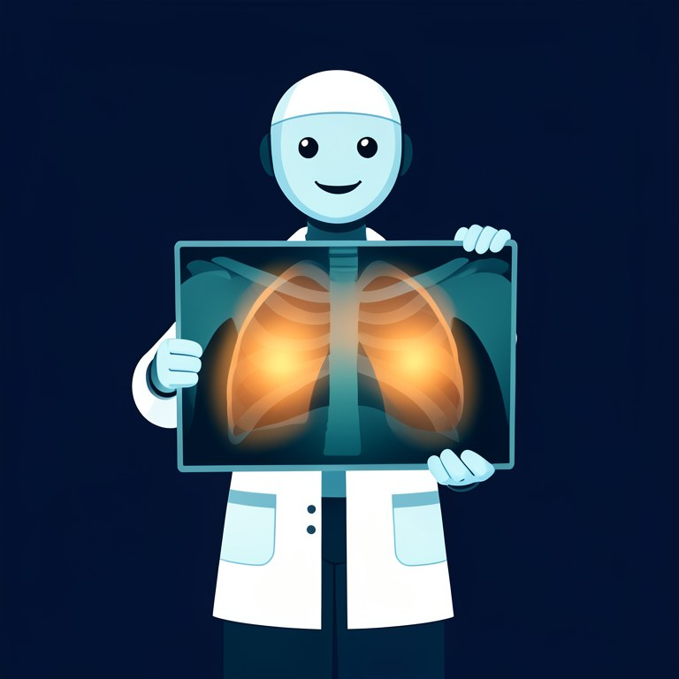

Illustrative image, generated with FLUX.2 [klein] 4B

## The CNNs you already trained

- Convolutions, feature maps, backpropagation — known from *Machine Learning and Recognition*.
- Our model: an ImageNet ResNet18, 1500 PneumoniaMNIST X-rays upsampled from 28 × 28 to 224 × 224, three epochs — test accuracy **0.861** on all 624.

Given a trained CNN, which **pixels** drove its decision?

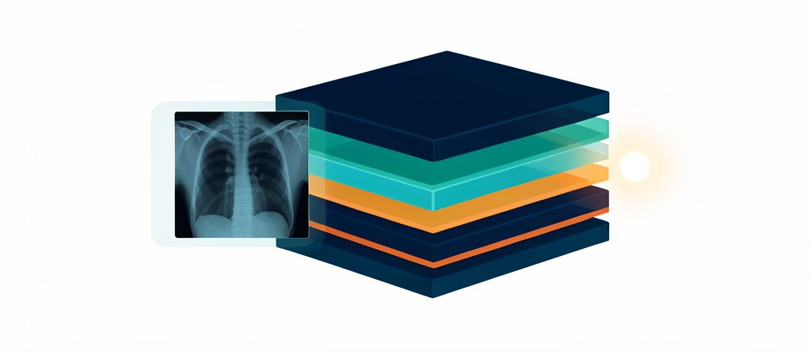

Illustrative image, generated with FLUX.2 [klein] 4B

CNN — convolutional neural network · ResNet18 — residual network with 18 layers · MNIST — the 28 × 28 image format of the MNIST digits (Modified NIST), which MedMNIST copies

## Occlusion sensitivity

- Slide a grey patch over the image, run the model, record how much the class score drops at each position.
- No gradients — only forward passes.
- The “level 0” explanation everything else has to beat.

$$H_{ij} = y_c(\mathbf x) - y_c\big(\mathbf x \text{ with the patch at } (i, j)\big)$$

**On our model:** a 4 × 4 patch in steps of 2 over the 28 × 28 X-ray — 13 × 13 = **169** forward passes. The pneumonia X-ray scores 7.8 in log-odds; the worst patch lowers it by 1.6.

Why log-odds and not the probability? At P = 1.000 no single patch moves the probability by more than 0.002.

Zeiler, Fergus (2014), [arXiv:1311.2901](https://arxiv.org/abs/1311.2901)

## Occlusion on two X-rays

[figure not shown]

## Occlusion — strengths and pitfalls

Use it when

- Any model, even a black box — only forward passes, no gradients.
- You ask the direct question: does hiding this region change the score?
- You test a suspected shortcut: cover the marker, watch the log-odds.

Watch out

- The grey square is a new image — the model never saw one in training.
- The fill value matters: black instead of grey moves the top patch to the middle.
- Patch size sets resolution and cost: 2 × 2 needs 729 passes, 8 × 8 only 36.
- Redundant evidence hides: cover one lung, the other still says pneumonia.

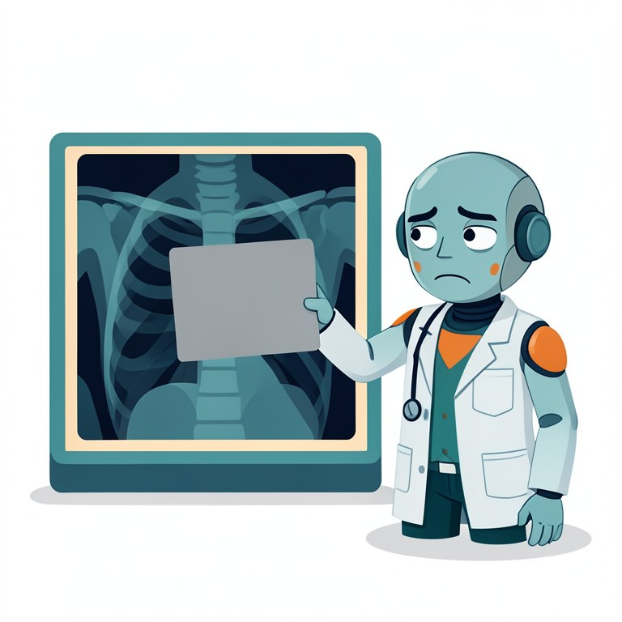

Illustrative image, generated with FLUX.2 [klein] 4B

On our pneumonia X-ray a black patch instead of a grey one gives a map with rank correlation only **0.59** to the original — report the patch, its fill and the score you occluded.

Zeiler, Fergus (2014) · Hooker et al. (2019), *A Benchmark for Interpretability Methods in Deep Neural Networks* (ROAR), [arXiv:1806.10758](https://arxiv.org/abs/1806.10758)

ROAR — RemOve And Retrain

## Grad-CAM and Integrated Gradients

|  | Grad-CAM | Integrated Gradients |
| --- | --- | --- |
| mechanism | the gradient of the class score weights the maps of the last convolutional block | gradients accumulated along a straight path from a baseline to the input |
| output | a coarse heatmap — “where the model looked” | an attribution per pixel |
| guarantee | none | sensitivity, implementation invariance, completeness |
| cost | one backward pass | $m$ backward passes |

Selvaraju et al. (2017), [arXiv:1610.02391](https://arxiv.org/abs/1610.02391) · Sundararajan, Taly, Yan (2017), [arXiv:1703.01365](https://arxiv.org/abs/1703.01365)

## The math behind Integrated Gradients

$$\mathrm{IG}_i(\mathbf x) = (x_i - x'_i)\cdot\frac{1}{m}\sum_{k=1}^{m} \frac{\partial f\big(\mathbf x' + \tfrac{k}{m}(\mathbf x - \mathbf x')\big)}{\partial x_i}$$

$\mathbf x'$ is the baseline (a black image), $m$ the number of steps.

**One pixel:** $x_i = 0.8$, $x'_i = 0$, gradients at four steps $0.20, 0.50, 0.70, 0.90$ — mean $0.575$, $\mathrm{IG}_i = 0.8 \cdot 0.575 = 0.46$. **Completeness:** the $\mathrm{IG}_i$ of all pixels add up to $f(\mathbf x) - f(\mathbf x')$ — local accuracy of SHAP, reached by calculus.

[figure not shown]

## Integrated Gradients — strengths and pitfalls

Use it when

- You need per-pixel attributions with axioms: completeness, sensitivity, implementation invariance.
- Gradients saturate: IG integrates along the path instead of one local slope.
- Any differentiable model — CNN, transformer, tabular network.

Watch out

- The baseline is the hidden knob: our model calls a black image pneumonia (P 0.997).
- Another baseline, another map: black vs. grey, rank correlation −0.12.
- Too few steps break completeness: at $m = 64$ still 11 % off.
- The maps keep the look of the input — read signs, not the picture.

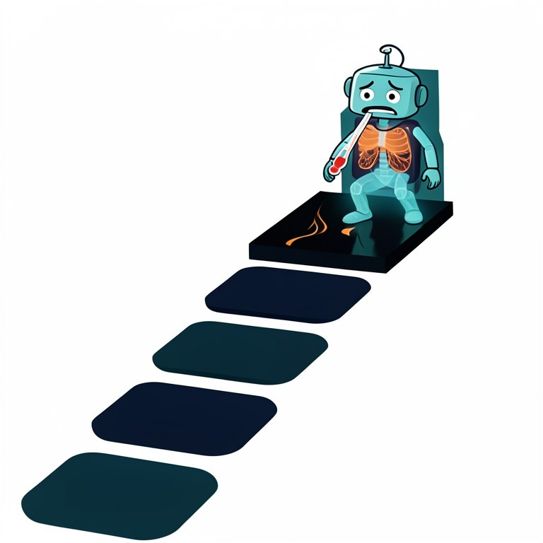

Illustrative image, generated with FLUX.2 [klein] 4B

Always state the baseline and check that the attributions add up to $f(\mathbf x) - f(\mathbf x')$.

Sturmfels, Lundberg, Lee (2020), *Visualizing the Impact of Feature Attribution Baselines*, [Distill](https://distill.pub/2020/attribution-baselines/) · Kindermans et al. (2019), [arXiv:1711.00867](https://arxiv.org/abs/1711.00867)

IG — Integrated Gradients

## The math behind Grad-CAM

$$\alpha_k^c = \frac{1}{Z}\sum_{i}\sum_{j} \frac{\partial y^c}{\partial A^k_{ij}}
\qquad\qquad
L^c_{\text{Grad-CAM}} = \mathrm{ReLU}\Big(\sum_k \alpha_k^c A^k\Big)$$

- $A^k$ — the $k$-th feature map of the last convolutional block, $Z$ its number of pixels; $y^c$ — the score of class $c$;
- $\alpha^c_k$ — the importance of map $k$ for class $c$: its gradient, averaged; ReLU keeps what pushes **towards** $c$.

**Two maps, one pixel:** gradients of map 1 are $0.1, 0.3, 0.2, 0.4$, so $\alpha_1 = 0.25$; map 2 has $\alpha_2 = -0.1$. A pixel with $A^1 = 2$, $A^2 = 3$: $0.25 \cdot 2 - 0.1 \cdot 3 = 0.2$, kept by the ReLU.

## Where does the model look?

[figure not shown]

## Grad-CAM — strengths and pitfalls

Use it when

- A CNN needs a map for every prediction: one forward, one backward pass.
- Class-discriminative: the pneumonia map differs from the normal one.
- Passes the sanity check — rank correlation 0.05 on our randomized model.
- Hunting shortcuts: markers, text labels, corners outside the body.

Watch out

- Coarse: a 7 × 7 grid upsampled — small lesions vanish.
- The ReLU hides counter-evidence: only regions pushing **towards** the class.
- Scaled to [0, 1] per image: there is always a hot spot, even when weak.
- Averaging the gradients can light up regions the model did not use.

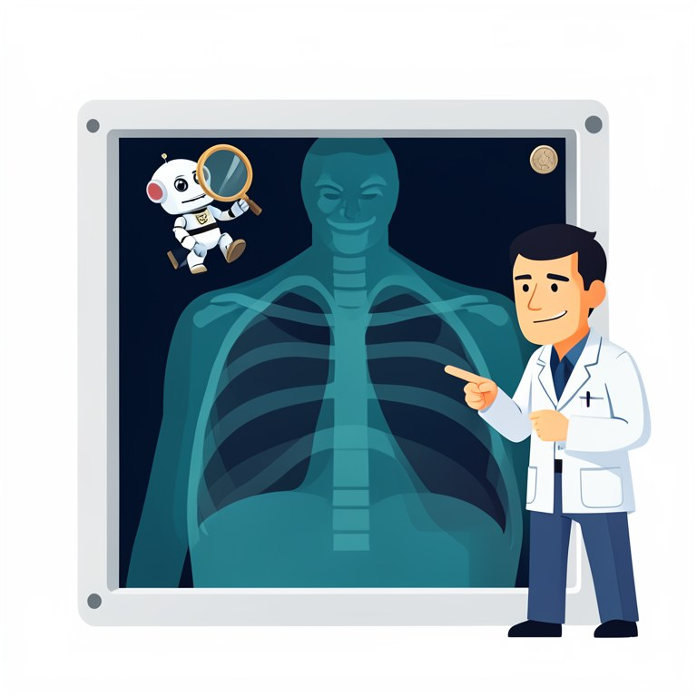

Illustrative image, generated with FLUX.2 [klein] 4B

A heatmap shows **where**, not **why** — and on our pneumonia X-ray Grad-CAM and occlusion agree only weakly (rank correlation 0.19).

Zech et al. (2018), [PLOS Med 15:e1002683](https://doi.org/10.1371/journal.pmed.1002683) · Draelos, Carin (2020), HiResCAM, [arXiv:2011.08891](https://arxiv.org/abs/2011.08891) · Saporta et al. (2022), [Nat Mach Intell 4:867](https://doi.org/10.1038/s42256-022-00536-x)

CAM — class activation mapping · HiResCAM — high-resolution CAM

## Interpretable by design — for images too

- Rudin’s argument, so far answered only for tables. For images?
- **ProtoPNet** learns a small set of prototypical image patches per class.
- At prediction time: “this looks like **that** prototype” — the explanation **is** the forward pass.

$$y_c = \sum_k w_{k,c}\,\max_{\text{patch}}\,\mathrm{sim}(\text{patch}, \mathbf p_k)$$

**input**

an X-ray patch

→

**compare**

with learned prototypes $\mathbf p_k$

→

**evidence**

“looks like that opacity”

Chen et al. (2019), *This Looks Like That*, [arXiv:1806.10574](https://arxiv.org/abs/1806.10574)

## Prototypes and concepts — strengths and pitfalls

Use it when

- The explanation should **be** the computation, not a post-hoc map.
- A clinician should audit the evidence: prototypes are real training patches.
- Concept bottleneck: predict clinical findings first, then the diagnosis from them.
- An expert can correct a wrong concept at test time.

Watch out

- “Looks like that” is similarity in latent space, not to a radiologist’s eye.
- A prototype can be a shortcut too: a marker, text, background.
- Concept bottlenecks need concept labels for every training image.
- Concepts can leak extra information — the bottleneck is less transparent than it looks.

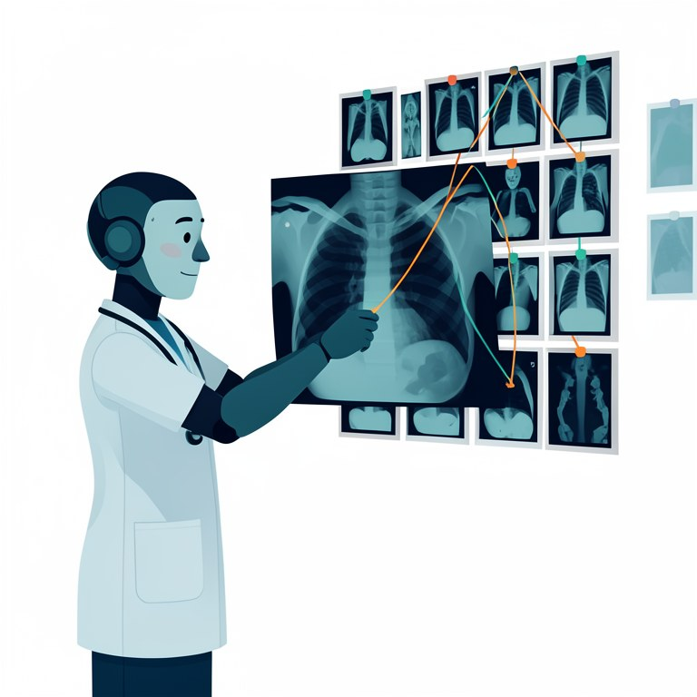

Illustrative image, generated with FLUX.2 [klein] 4B

A prototype explains only if a clinician agrees that the two patches look alike — check a few by eye before you trust the “this looks like that”.

Koh et al. (2020), *Concept Bottleneck Models*, [arXiv:2007.04612](https://arxiv.org/abs/2007.04612) · Hoffmann et al. (2021), [arXiv:2105.02968](https://arxiv.org/abs/2105.02968) · Mahinpei et al. (2021), [arXiv:2106.13314](https://arxiv.org/abs/2106.13314)

## 5 · When not to trust an explanation

> A plausible explanation and a faithful one are not the same thing.

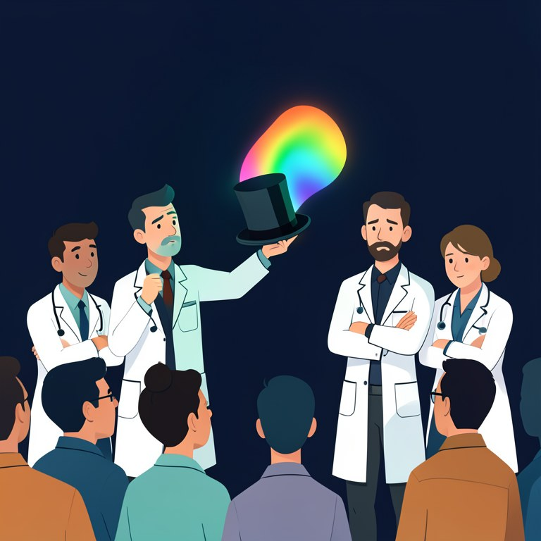

Illustrative image, generated with FLUX.2 [klein] 4B

## Do these explanations mean anything?

- A **sanity check:** destroy part of the model — re-initialize its last layers — and compute the explanation again for the same input.
- If the map barely changes, it never described the model: it describes the **input** — edges, contrast, anatomy.
- A second check: **delete** the pixels the map calls most important, in order, and watch the score fall — a faithful map makes it fall fast.
- Why it matters in the clinic: see *Do explanations help the clinician?*

Adebayo et al. (2018), *Sanity Checks for Saliency Maps*, [arXiv:1810.03292](https://arxiv.org/abs/1810.03292) · Petsiuk et al. (2018), RISE, deletion curves, [arXiv:1806.07421](https://arxiv.org/abs/1806.07421)

RISE — Randomized Input Sampling for Explanation

## Gradients, SmoothGrad, guided backprop

- **Vanilla gradient:** $\partial y_c / \partial \mathbf x$ — noisy and speckled, but it **changes** when the model is destroyed.
- **SmoothGrad:** average over noisy copies — less speckle.
- **Guided backpropagation:** let only positive gradients through the ReLUs — sharp, pretty maps that **barely change** on a destroyed model.

$$\hat S(\mathbf x) = \frac{1}{n}\sum_{k=1}^{n} \nabla_{\mathbf x} y_c(\mathbf x + \boldsymbol\varepsilon_k), \quad \boldsymbol\varepsilon_k \sim \mathcal N(\mathbf 0, \sigma^2 I)$$

**Adebayo et al.:** gradients and Grad-CAM **pass** the sanity checks; guided backprop and guided Grad-CAM **fail** — they look the same on a model that has learned nothing.

Integrated Gradients sits in between: its maps keep the look of the input, only their signs change.

Noisy is not the same as wrong, and pretty is not the same as right.

Smilkov et al. (2017), SmoothGrad, [arXiv:1706.03825](https://arxiv.org/abs/1706.03825) · Springenberg et al. (2015), guided backprop, [arXiv:1412.6806](https://arxiv.org/abs/1412.6806)

## Trained vs. randomized

[figure not shown]

At 28 × 28 the rows differ less to the eye than the numbers say — the rank correlation over 20 test X-rays is the test.

## Gradient maps — strengths and pitfalls

Use it when

- A first look at pixel-level sensitivity, finer than Grad-CAM’s 7 × 7.
- Vanilla gradient: one backward pass, and it passes the sanity check (0.14).
- SmoothGrad: the gradient is too speckled to read.

Watch out

- A gradient is a local slope: saturated pixels get zero though they matter.
- SmoothGrad has knobs — noise $\sigma$ and $n$ copies — and costs $n$ passes.
- Guided backprop draws the input’s edges, not the model (0.94).
- Taking the absolute value loses the sign: for or against the class.

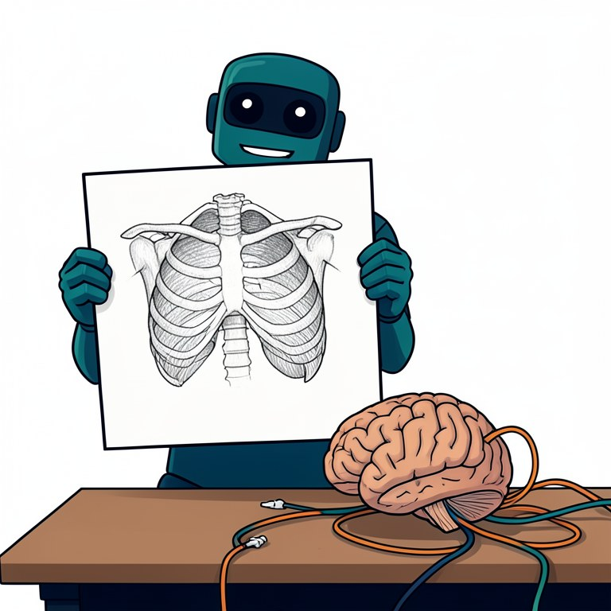

Illustrative image, generated with FLUX.2 [klein] 4B

Before you trust any map, run the randomization test of the previous slide — on our model it takes seconds.

Sundararajan, Taly, Yan (2017), saturation · Nie, Zhang, Patel (2018), [arXiv:1805.07039](https://arxiv.org/abs/1805.07039)

## Do explanations help the clinician?

- **Automation bias:** people over-trust an automated output and follow it even when it is wrong.
- A heatmap shows **where**, not **what** or **why** — the clinician fills in the why with a plausible story of their own.
- So use explanations to **audit and debug** a model across many cases — not as proof that one prediction is right.

**Jabbour et al. (2023)** — randomized vignettes, 457 clinicians, patients with acute respiratory failure, Grad-CAM heatmaps on the X-ray.

- Baseline accuracy: **73.0 %**
- Standard model: **+2.9** points; with explanations **+4.4**
- Systematically biased model: **−11.3** points
- Biased model + explanations: **−9.1** — the 2.3-point rescue is **not significant**

Ghassemi, Oakden-Rayner, Beam (2021), *The false hope of current approaches to explainable artificial intelligence in health care*, Lancet Digit Health, doi:10.1016/S2589-7500(21)00208-9 · Jabbour et al. (2023), *Measuring the Impact of AI in the Diagnosis of Hospitalized Patients*, JAMA, [doi:10.1001/jama.2023.22295](https://doi.org/10.1001/jama.2023.22295)

## Is attention an explanation?

- Transformers come with a built-in-looking explanation: **attention weights**.
- Tempting to read high attention as “the reason” — but attention need not track a feature’s effect on the output.
- **Jain & Wallace (2019):** very different attention, the same prediction. **Wiegreffe & Pinter (2019):** it depends on how you test it.

[figure not shown]

Jain, Wallace (2019), [arXiv:1902.10186](https://arxiv.org/abs/1902.10186) · Wiegreffe, Pinter (2019), [arXiv:1908.04626](https://arxiv.org/abs/1908.04626)

## 6 · What to take home

> An explanation is a claim about the model. Check it like any other claim.

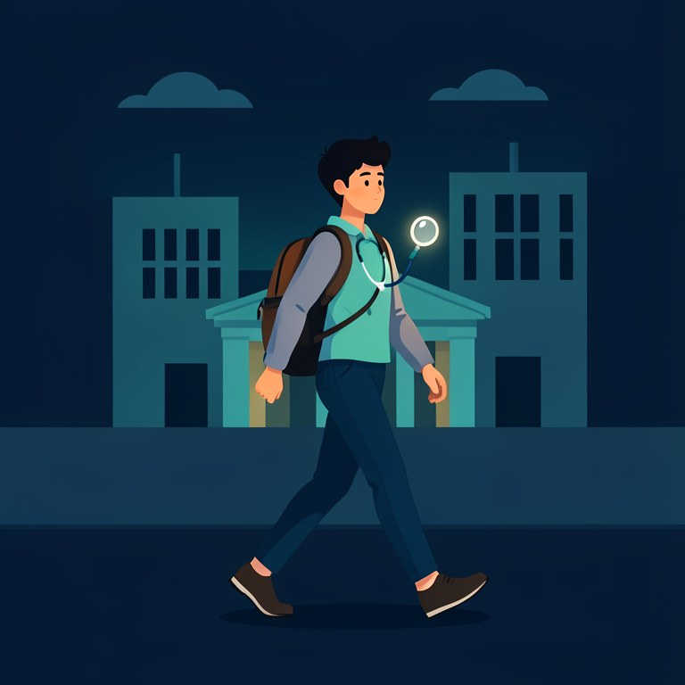

Illustrative image, generated with FLUX.2 [klein] 4B

## Takeaways

1. **Choose before you explain.** Clinicians trust point scores; on our data logistic regression matched XGBoost and needs no explanation.
2. **Global and local are different questions.** Permutation importance, PDP and the beeswarm describe the model; a waterfall, LIME, a counterfactual one patient.
3. **Correlated features share or steal the credit.** An exact copy of “vessels” got 0.000 — look at the correlations before any ranking.
4. **An explanation describes the model, not the patient** — not causal, and perturbations ask about patients who do not exist.
5. **Report the knob and the quality number** — kernel, baseline, fill; precision, held-out fidelity.
6. **Use maps to debug, after a sanity check.** Ours pointed at a corner outside the body; guided backprop ignored a destroyed model.

## Quick check

1. Logistic regression and XGBoost both scored 0.868. Which would you deploy, and why?
2. Fasting blood sugar has a permutation importance of 0.000. Does that mean it is clinically irrelevant?
3. The SHAP values of a patient add up to what, exactly?
4. Why can a PDP show combinations of age and heart rate that no patient has?
5. “Age > 55 AND cholesterol > 240” fires on 27 % of patients. Why is it a poor anchor for our model?
6. You add an exact copy of “vessels” as a 14th feature and retrain. What happens to the permutation importance of the two copies?
7. A saliency method gives the same map for the trained and the randomized model. What does it explain?
8. NEWS2 gives a patient 6 points. What is the explanation — and what does the chart not see?

## The lab and the sources

### The lab — two parts

1. **SHAP vs. an interpretable model** — logistic regression and XGBoost on Heart Disease, coefficients against SHAP.
2. **Grad-CAM by hand, then the trust exercise** — the ResNet18, Grad-CAM in fifteen lines, and a quiz: which map comes from the real model?

[Lab page](https://github.com/tomasvicar/AUI-public/tree/master/labs/explainability) · [`heart.py`](https://github.com/tomasvicar/AUI-public/blob/master/lectures/explainability/code/heart.py) · [`pneumonia.py`](https://github.com/tomasvicar/AUI-public/blob/master/lectures/explainability/code/pneumonia.py) — every number of the lecture

### Reading

- C. Molnar, [*Interpretable Machine Learning*](https://christophm.github.io/interpretable-ml-book/) — the whole landscape;
- Rudin (2019), [arXiv:1811.10154](https://arxiv.org/abs/1811.10154);
- Lundberg, Lee (2017), [arXiv:1705.07874](https://arxiv.org/abs/1705.07874) — SHAP;
- Ribeiro et al. (2016), [arXiv:1602.04938](https://arxiv.org/abs/1602.04938) — LIME;
- Selvaraju et al. (2017), [arXiv:1610.02391](https://arxiv.org/abs/1610.02391) — Grad-CAM;
- Sundararajan et al. (2017), [arXiv:1703.01365](https://arxiv.org/abs/1703.01365) — IG;
- Adebayo et al. (2018), [arXiv:1810.03292](https://arxiv.org/abs/1810.03292) — sanity checks.